Reports:

BTC/USD - DOGE/USD BTC/USD - XRP/USD DOGE/USD - ADA/USD DOGE/USD - XRP/USD ETH/USD - ADA/USD ETH/USD - DOGE/USD ETH/USD - SOL/USD LTC/USD - ADA/USD SOL/USD - DOGE/USD XRP/USD - ADA/USD

# Pairs Trading Report: ETH-USD / ADA-USD

**Nicolò Blasco Pecoraro**

**21 luglio 2025**

## 1. Strategy Overview

This report analyzes the performance of a pairs trading strategy between the following assets:

- **Asset 1**: ETH-USD
- **Asset 2**: ADA-USD

We use daily log-prices and model their spread using a linear regression.  
Entry and exit thresholds are based on z-score deviations:

- **Entry Threshold**: 1.5
- **Exit Threshold**: 0.5

## 2. Strategy Logic & Execution

This section outlines the core logic behind the pairs trading strategy.

We estimate the relationship between the two assets using a linear regression on log-prices.  
The spread (i.e., residual) from this model is then used to compute a **z-score**,  
which serves as the signal for both entry and exit decisions.

The trading positions and their resulting returns are calculated accordingly.

## 3. Strategy Performance

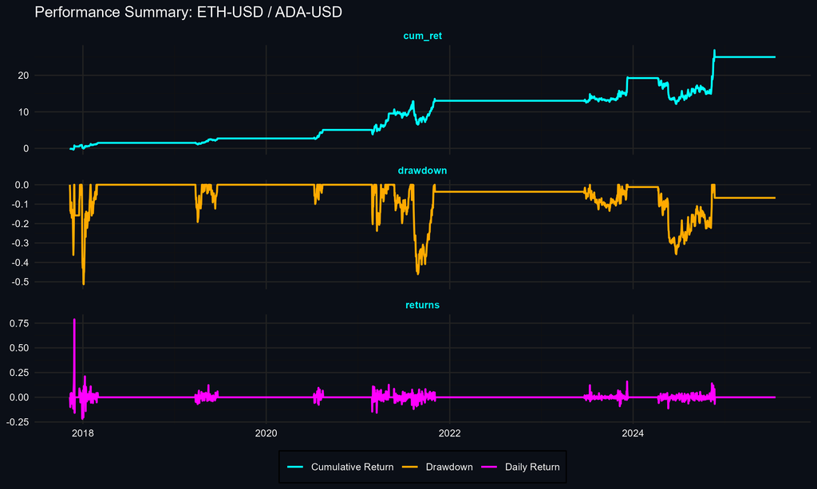

### Performance Metrics Table

Strategy Performance Metrics

| Total Return (%) | Annualized Sharpe | Max Drawdown |
| --- | --- | --- |
| 2500 | 0.82 | 0.513 |

## 4. Interpretation

This section provides a qualitative interpretation of the strategy’s performance, using the Sharpe Ratio as a key metric.

The strategy offers reasonable potential for generating returns that compensate for the risk taken. While the Sharpe Ratio is below the ideal threshold of 1, the model could still be viable under certain market conditions, especially if further optimized or paired with complementary strategies to reduce drawdown.

## 5. Volatility Profile & Risk Evaluation

This section evaluates the volatility structure of the strategy returns. Here are reported key indicators such as standard deviation, realized volatility, annualized volatility, mean return per trade, and number of trades.  
These indicators help assess the overall risk profile of the pair.

Volatility Metrics of the Strategy

| Standard.Deviation | Realized.Volatility | Annualized.Volatility | Mean.Return.per.Trade | Number.of.Trades |
| --- | --- | --- | --- | --- |
| 0.026 | 1.39 | 0.415 | 0.001 | 16 |

### Volatility Commentary

The strategy exhibits **moderate volatility**, suggesting a balanced exposure profile. This level of risk is generally acceptable in practical applications.

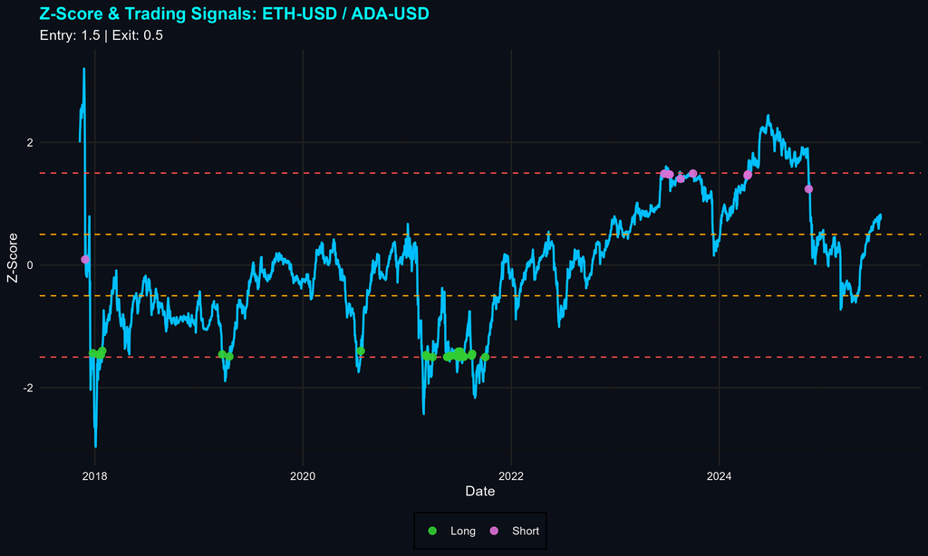

## 6. Conclusion

This report demonstrated the use of a **mean-reversion pairs trading strategy** on selected cryptocurrency pairs.

We applied a **dynamic entry-exit logic** based on z-scores, measured key risk-adjusted metrics, and generated performance summaries.

This framework is designed to be **reusable**.  
By uploading a different crypto pair and running the optimization pipeline, a new report can be produced automatically.

## Usefull Links

[Yahoo Finance Crypto](https://finance.yahoo.com/cryptocurrencies/) | [CoinMarketCap](https://coinmarketcap.com/) | [TradingView](https://www.tradingview.com/markets/cryptocurrencies/prices-all/)